# P8105_hw3_rl3328

# Problem 2

```r
data("brfss_smart2010")
brfss_smart2010 = brfss_smart2010 |> as.tibble()
```

First, do some data cleaning:

format the data to use appropriate variable names; focus on the “Overall Health” topic include only responses from “Excellent” to “Poor” organize responses as a factor taking levels ordered from “Poor” to “Excellent”

```r
res_order =c("Excellent","Very good","Good","Fair","Poor")
brfss_smart2010 = brfss_smart2010 |> janitor::clean_names() |>
  filter(topic == "Overall Health" & response %in% res_order) |> arrange(factor(response, levels = res_order))
```

Using this dataset, do or answer the following (commenting on the results of each):

In 2002, which states were observed at 7 or more locations? What about in 2010?

```r
a = brfss_smart2010 |>filter(year == 2002) |> group_by(locationabbr,locationdesc) |> summarise(n=n()) |>
  arrange(desc(n))
b = brfss_smart2010 |>filter(year == 2002) |> group_by(locationabbr) |> summarise(n=n()) |>
  arrange(desc(n))
b1 = b |> filter((n/5) >= 7)
```

- I found that every location(with county) appears 5 times per year in this dataset. So, I can calculate how many locations a state was observed by knowing the times each state appears per year.
- In 2002, 6 states were observed at 7 or more locations, they are PA, MA, NJ, CT, FL, NC.

```r
c = brfss_smart2010 |>filter(year == 2010) |> group_by(locationabbr,locationdesc) |> summarise(n=n()) |>
  arrange(desc(n))
d = brfss_smart2010 |>filter(year == 2010) |> group_by(locationabbr) |> summarise(n=n()) |>
  arrange(desc(n))
d1 = d |> filter((n/5) >= 7)
```

- Similarly, in 2010, 14 states were observed at 7 or more locations, they are FL, NJ, TX, CA, MD, NC, NE, WA, MA, NY, OH, CO, PA, SC.

Construct a dataset that is limited to Excellent responses, and contains, year, state, and a variable that averages the data_value across locations within a state. Make a “spaghetti” plot of this average value over time within a state (that is, make a plot showing a line for each state across years – the geom_line geometry and group aesthetic will help).

```r
brfss = brfss_smart2010 |>
  filter(response == "Excellent") |>
  group_by(year,locationabbr) |>
  summarise(data_value_within_state = mean(data_value,rm.na = T))
```

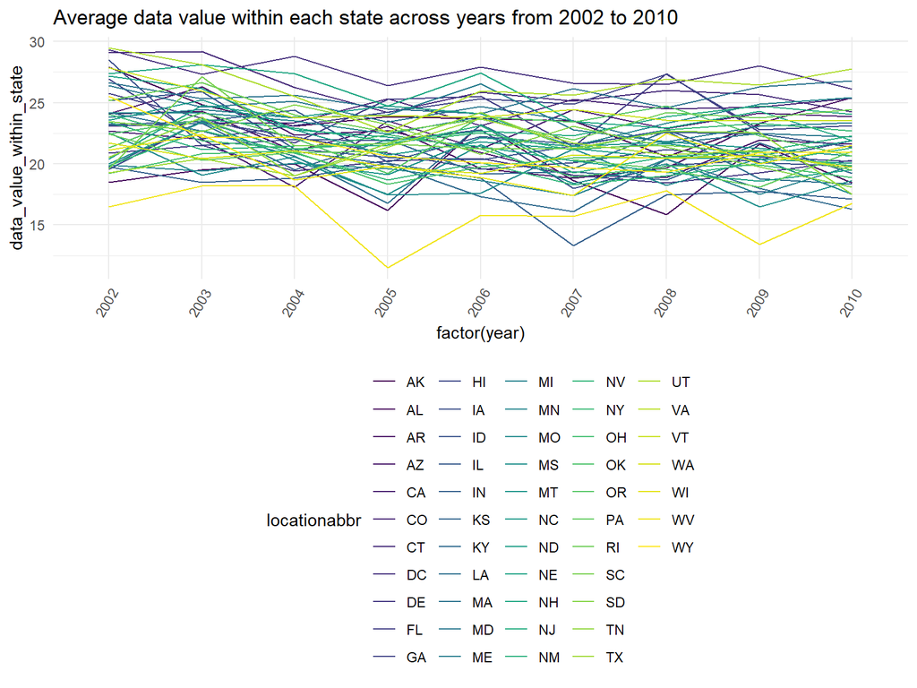

```r
gp_brfss = brfss |>
  ggplot(aes(x = factor(year), y = data_value_within_state, color= locationabbr, group = locationabbr)) +
  geom_line() +
  labs(title = "Average data value within each state across years from 2002 to 2010") +
  theme(
    axis.text.x = element_text(angle = 60, hjust = 1))

print(gp_brfss)
```

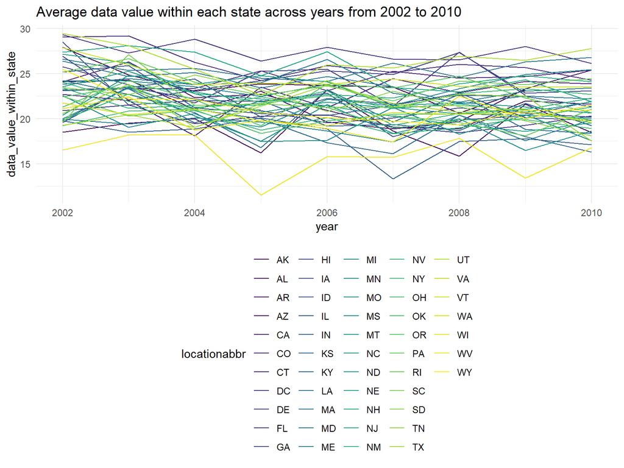

```r
gp = brfss |>
  ggplot(aes(x = year, y = data_value_within_state, color= locationabbr, group = locationabbr)) + geom_line()+
  labs(title = "Average data value within each state across years from 2002 to 2010")

print(gp)
```

Make a two-panel plot showing, for the years 2006, and 2010, distribution of data_value for responses (“Poor” to “Excellent”) among locations in NY State

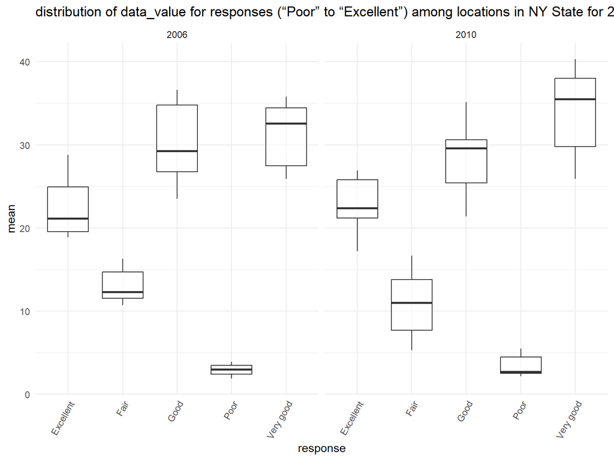

```r
brfss_smart2010 |>
  filter(year %in% c(2006,2010) & locationabbr == "NY") |>
  group_by(year,response, locationdesc) |>
  summarize(mean = mean(data_value, rm.na=T)) |>
  mutate(response = forcats::fct_relevel(response, res_order)) |>
  ggplot(aes(x = response, y = mean)) +
  geom_boxplot(alpha = .5) +
  facet_grid(. ~ year) +
  labs(title = "distribution of data_value for responses (“Poor” to “Excellent”) among locations in NY State for 2006 and 2010") +
  theme(
    axis.text.x = element_text(angle = 60, hjust = 1))
```

# Problem 3

Load, tidy, merge, and otherwise organize the data sets. Your final dataset should include all originally observed variables; exclude participants less than 21 years of age, and those with missing demographic data; and encode data with reasonable variable classes (i.e. not numeric, and using factors with the ordering of tables and plots in mind).

```r
demo = read_csv("./hw3_data/nhanes_covar.csv") |>
  janitor::row_to_names(row_number = 4) |>
  janitor::clean_names() |>
  filter(age >= 21) |>
  drop_na() |>
  mutate(
    sex = recode(sex, "1" = "male", "2" = "female"),
    education = recode(education, "1" = "less than high school", "2" = "high school equivalent", "3" = "more than high school"),
    age = as.numeric(age))
```

```
## ──────────────────────────────────────────────────────── Delimiter: "," chr
## (5): ...1, 1 = male, ...3, ...4, 1 = Less than high school
```

```r
accel = read_csv("./hw3_data/nhanes_accel.csv") |>
  janitor::clean_names()|>
  mutate(seqn = as.character(seqn))
```

Produce a reader-friendly table for the number of men and women in each education category, and create a visualization of the age distributions for men and women in each education category. Comment on these items.

```r
table(demo$sex,demo$education) |>
  knitr::kable()
```

|  | high school equivalent | less than high school | more than high school |
| --- | --- | --- | --- |
| female | 23 | 28 | 59 |
| male | 35 | 27 | 56 |

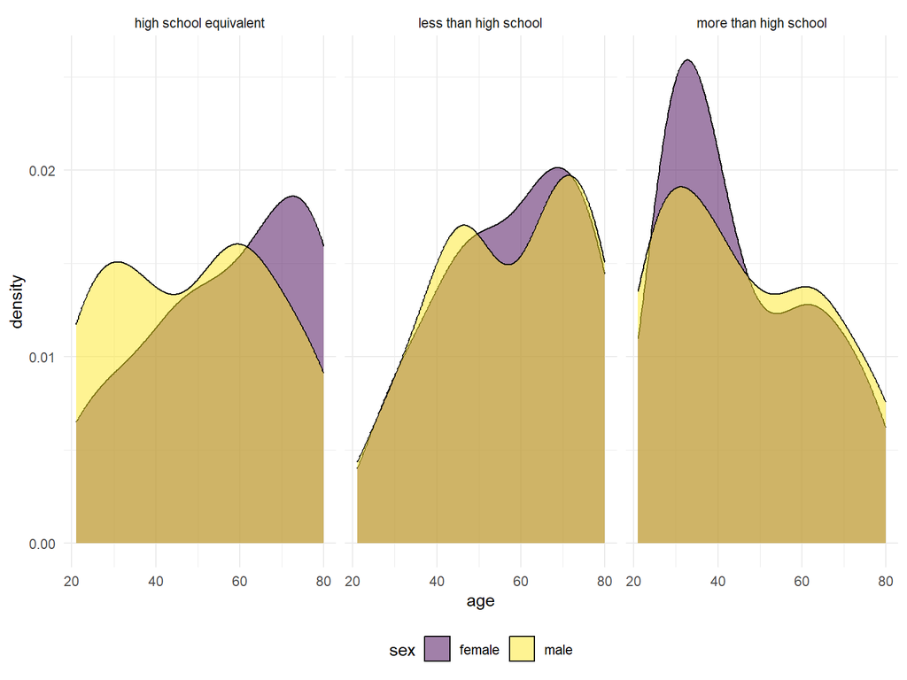

```r
demo |>
  ggplot(aes(x = age, fill = sex)) +
  geom_density(alpha=0.5) +
  facet_grid(. ~ education)
```

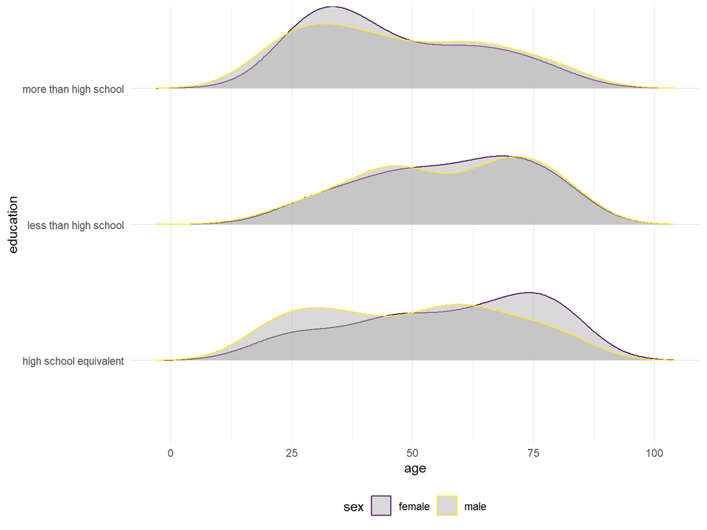

```r
demo |>
  ggplot(aes(x=age, y=education, color=sex))+
  geom_density_ridges(scale = 0.6,alpha=.5)
```

* Compared to males, female participants have lower proportion of high school equivalent education; People with more than high school education ar more likely to get involved in this study. * Overall, male participants have higher heterogeneity in age across all educational level, especially among less than and equal high school education level compared with females. Age distribution is more sparse in more than high school education level compared with other two education levels bot for males and females.

Traditional analyses of accelerometer data focus on the total activity over the day. Using your tidied dataset, aggregate across minutes to create a total activity variable for each participant. Plot these total activities (y-axis) against age (x-axis); your plot should compare men to women and have separate panels for each education level. Include a trend line or a smooth to illustrate differences. Comment on your plot.

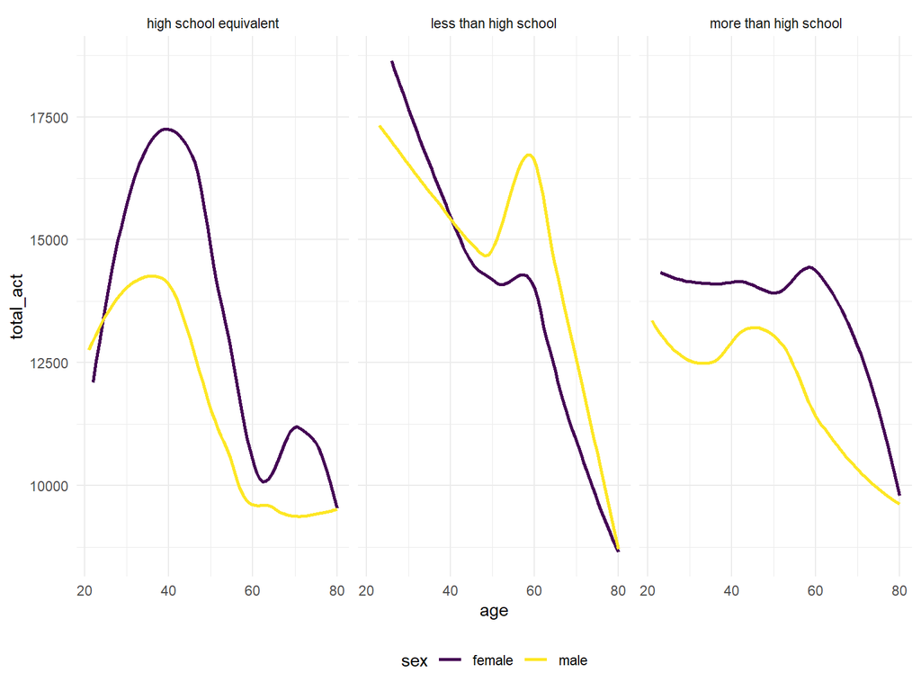

```r
accel_long =  accel |>
  pivot_longer(
    -seqn,
    names_to = "time",
    values_to = "value"
  )

demo_accel = left_join(demo, accel_long, by = "seqn")

demo_accel |>
  group_by(seqn,age,sex,education) |>
  summarise(total_act = sum(value)) |>
  ggplot(aes(x= age, y = total_act, color = sex)) +
  geom_smooth(aes(group =sex), se = FALSE) +
  facet_grid(. ~ education)
```

Accelerometer data allows the inspection activity over the course of the day. Make a three-panel plot that shows the 24-hour activity time courses for each education level and use color to indicate sex. Describe in words any patterns or conclusions you can make based on this graph; including smooth trends may help identify differences

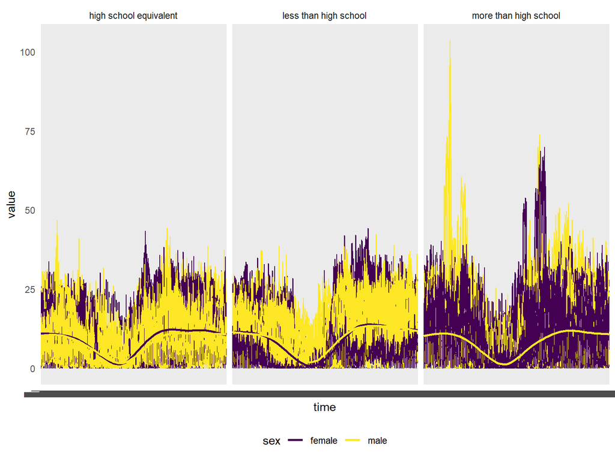

```r
demo_accel |>
  ggplot(aes(x = time, y = value,group=seqn, color = sex)) +
  geom_line() +
  geom_smooth(aes(group =sex), se = FALSE) +
  facet_grid(. ~ education)
```

- generally, the overall activity over the course of the day of participants decreases as their age become older. The effect of age on total activity is mitigated among the more than high school education level.